# **30535 Skills Problem Set 1**

### 1.2

Completed the quizzes on canvas

### 2.1

```r
# Loading Packages
library(tidyverse)
```

### 2.1.1

```r
# Calculate rows in mpg
nrow(mpg)
```

```
## [1] 234
```

```r
# Calculate columns in mpg
ncol(mpg)
```

```
## [1] 11
```

```r
# View the structure of mpg
str(mpg)
```

```
## tibble [234 × 11] (S3: tbl_df/tbl/data.frame)
##  $ manufacturer: chr [1:234] "audi" "audi" "audi" "audi" ...
##  $ model       : chr [1:234] "a4" "a4" "a4" "a4" ...
##  $ displ       : num [1:234] 1.8 1.8 2 2 2.8 2.8 3.1 1.8 1.8 2 ...
##  $ year        : int [1:234] 1999 1999 2008 2008 1999 1999 2008 1999 1999 2008 ...
##  $ cyl         : int [1:234] 4 4 4 4 6 6 6 4 4 4 ...
##  $ trans       : chr [1:234] "auto(l5)" "manual(m5)" "manual(m6)" "auto(av)" ...
##  $ drv         : chr [1:234] "f" "f" "f" "f" ...
##  $ cty         : int [1:234] 18 21 20 21 16 18 18 18 16 20 ...
##  $ hwy         : int [1:234] 29 29 31 30 26 26 27 26 25 28 ...
##  $ fl          : chr [1:234] "p" "p" "p" "p" ...
##  $ class       : chr [1:234] "compact" "compact" "compact" "compact" ...
```

*Interpretation*  
Each row represents an observation in the dataset, and each column represents a variable of observations in the dataset.

### 2.1.2

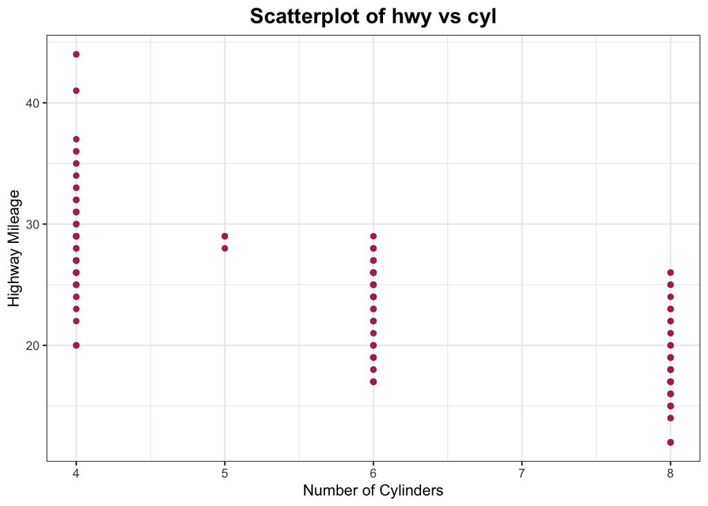

```r
# Scatterplot of hwy vs cyl
ggplot(mpg) +
  geom_point(mapping= aes(cyl, hwy), col = "maroon") +
  labs(title= "Scatterplot of hwy vs cyl",
       x = "Number of Cylinders",
       y = "Highway Mileage") +
  theme_bw() +
  theme(plot.title = element_text(size = 15, face = "bold", hjust = 0.5))
```

### 2.1.3

```r
#Interpret variable drv
?mpg
table(mpg$drv) # Find the distribution of drv types
```

```
##
##   4   f   r
## 103 106  25
```

```r
table(mpg$class) # Find the distribution of class types
```

```
##
##    2seater    compact    midsize    minivan     pickup subcompact        suv
##          5         47         41         11         33         35         62
```

*Interpretation*  
With help of r function, we know that the variable *drv* describes the type of drive train the car uses, of which *f* means *front-wheel drive*, *r* means *rear wheel drive* and *4* means *four-wheel drive*

### 2.1.4

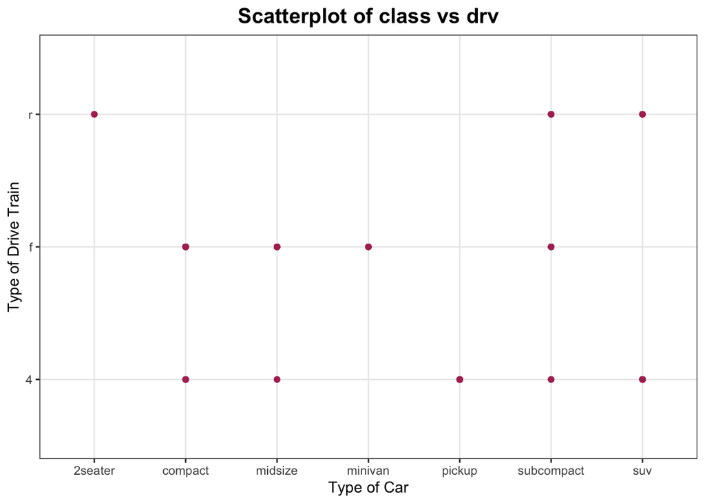

```r
# Scatterplot of drv vs class
ggplot(mpg) +
  geom_point(mapping= aes(class, drv), col = "maroon") +
  labs(title = "Scatterplot of class vs drv",
       x = "Type of Car",
       y = "Type of Drive Train") +
  theme_bw() +
  theme(plot.title = element_text(size = 15, face = "bold", hjust = 0.5))
```

```r
# I set the variable which has more categories, i.e. class, as the x variable to
# make the plot more readable
```

*Reference*  
https://stats.stackexchange.com/questions/123938/how-to-determine-which-variable-goes-on-the-x-y-axes-in-a-scatterplot

*Interpretation*  
The plot is not that useful because both *class* and *drv* are categorical variables. This means that we cannot observe how many points are for each combination. What we could observe in the plot is the combination types of *The type of car* and *The type of drive train*, which are at most $3\times7 = 21$ in this case.  
Besides, the type of car does not usually determine the type of drive. We only observe 12 types of combination in the plot and most classes are paired with multiple types of drive.We could not conclude any correlation between the two factors.

### 2.2

### 2.2.1

```r
?mpg # Pull up the documentation
print(mpg) # View the first 10 rows
```

```
## # A tibble: 234 × 11
##    manufacturer model      displ  year   cyl trans drv     cty   hwy fl    class
##    <chr>        <chr>      <dbl> <int> <int> <chr> <chr> <int> <int> <chr> <chr>
##  1 audi         a4           1.8  1999     4 auto… f        18    29 p     comp…
##  2 audi         a4           1.8  1999     4 manu… f        21    29 p     comp…
##  3 audi         a4           2    2008     4 manu… f        20    31 p     comp…
##  4 audi         a4           2    2008     4 auto… f        21    30 p     comp…
##  5 audi         a4           2.8  1999     6 auto… f        16    26 p     comp…
##  6 audi         a4           2.8  1999     6 manu… f        18    26 p     comp…
##  7 audi         a4           3.1  2008     6 auto… f        18    27 p     comp…
##  8 audi         a4 quattro   1.8  1999     4 manu… 4        18    26 p     comp…
##  9 audi         a4 quattro   1.8  1999     4 auto… 4        16    25 p     comp…
## 10 audi         a4 quattro   2    2008     4 manu… 4        20    28 p     comp…
## # … with 224 more rows
```

*Interpretation*

- categorical: chr
- continuous: dbl,int. dbl stands for double, and int stands for integer.

### 2.2.2

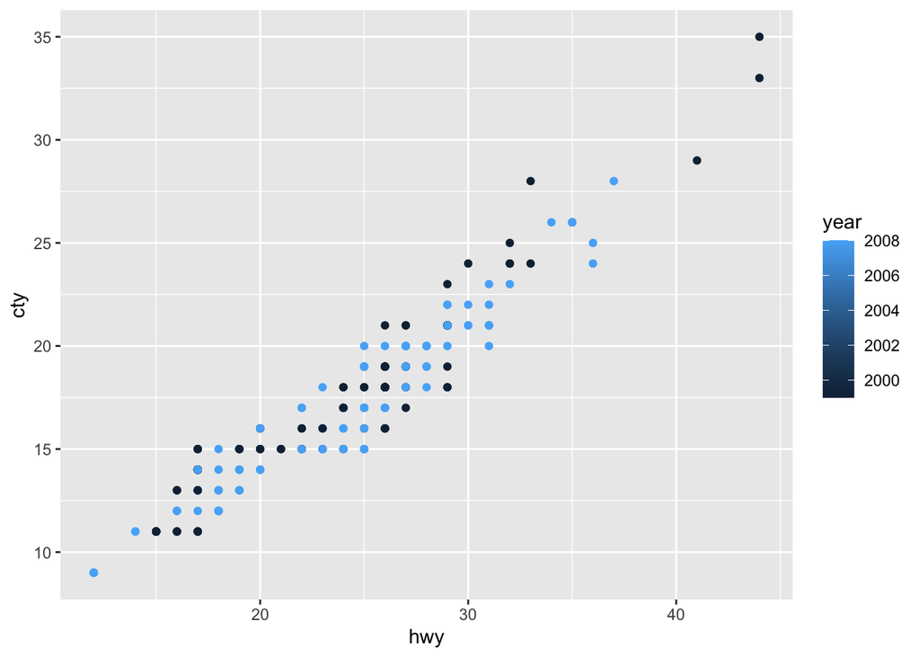

```r
# Run the code provided
# Graph 1
ggplot(data = mpg) +
  geom_point(mapping = aes(x = hwy, y = cty, color = year))
```

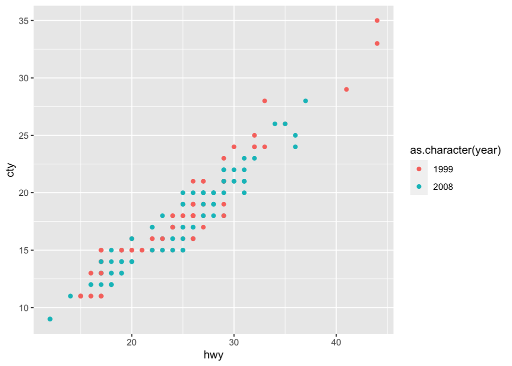

```r
# Graph 2
ggplot(data = mpg) +
  geom_point(mapping = aes(x = hwy, y = cty, color = as.character(year)))
```

```r
# Find the type of year
class(mpg$year)
```

```
## [1] "integer"
```

*Interpretation*